# GLM-Based Analysis of the Memory Words Task from the MSC Dataset

John Koo

Source code for this document can be found at https://github.com/johneverettkoo/stats-hw/tree/master/stat-s681

For this analysis, we will focus on session 1 for subject 1. We will look at the T1-weighted scans. This particular session consisted of 121 scans of $38 \times 49 \times 38$ voxels. Each voxel is $4 \times 4 \times 4$ mm. The scans were taken at $2.2$ second intervals.

# EDA

Brain mask:

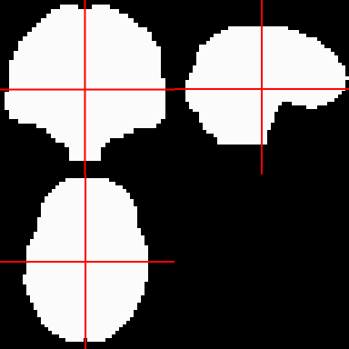

| . | Freq |
| --- | --- |
| 0 | 43716 |
| 1 | 27040 |

| . | Freq |
| --- | --- |
| 0 | 0.6178 |
| 1 | 0.3822 |

Regressors:

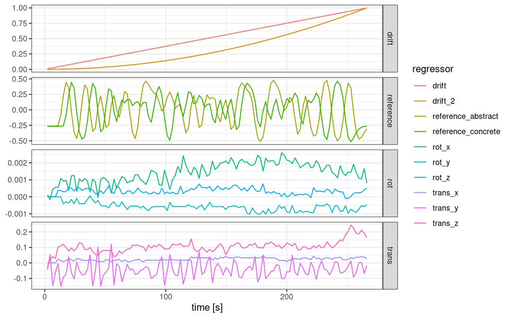

# GLM Results and Diagnostics

The model used for this analysis is:

$$Y = X \beta + E$$

Using the two $\beta_{task}$ estimates for each voxel, we can try constructing contrast maps. Hopefully we’ll be able to see contiguous zones that correspond to abstract vs. concrete.

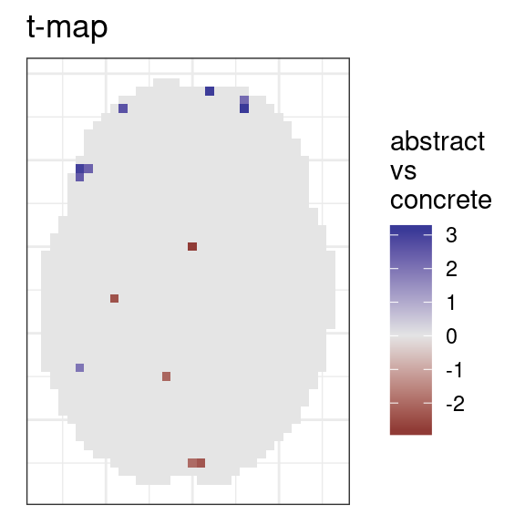

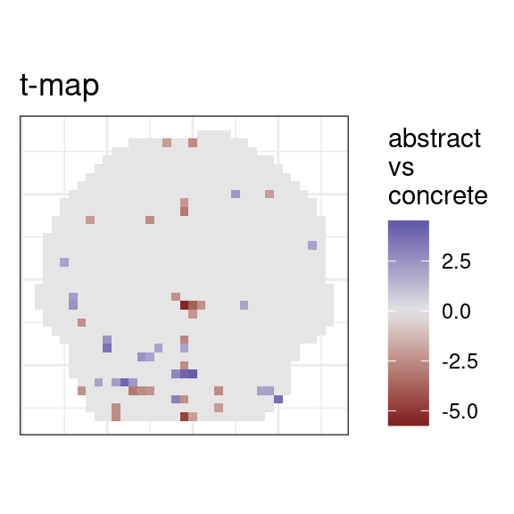

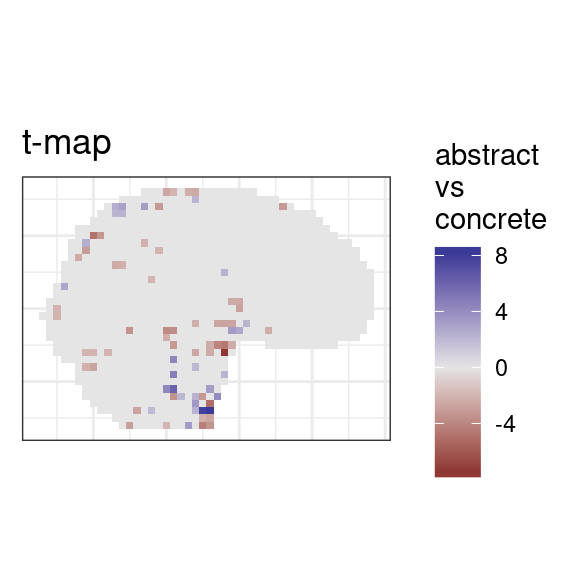

Under the null hypothesis, the two $\beta_{task}$ estimates should be approximately $t$-distributed when divided by their standard errors. We can check visually whether this is the case:

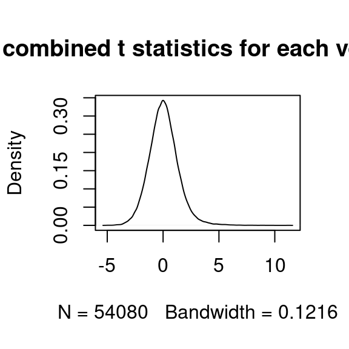

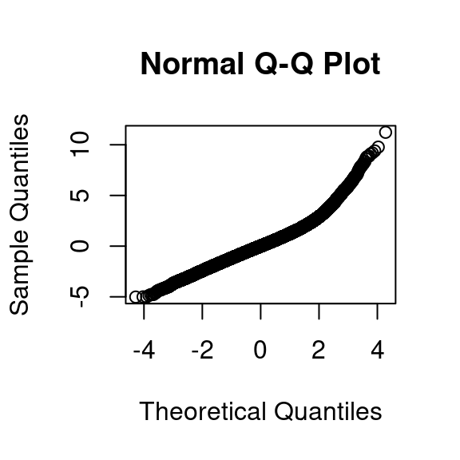

Setting the significance level $\alpha = 0.05$, we can construct $t$-maps:

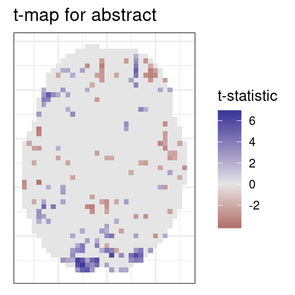

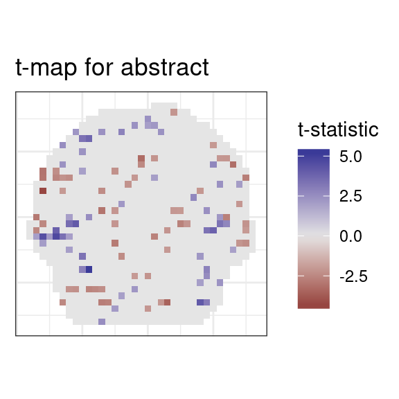

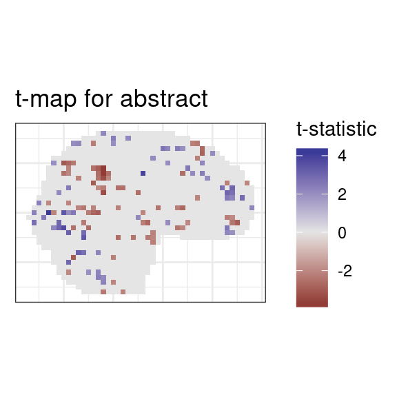

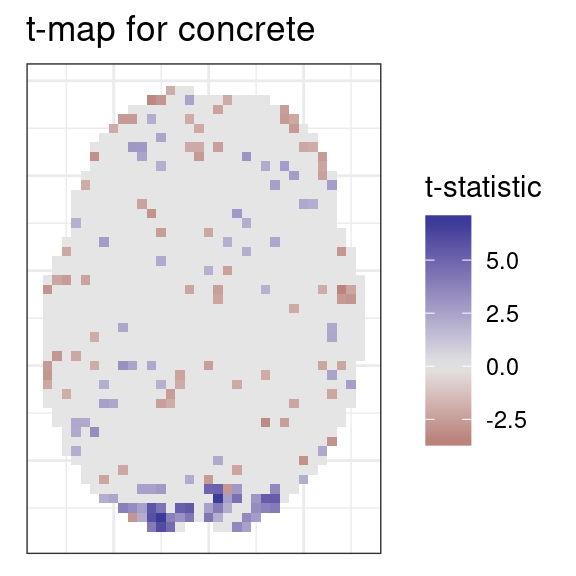

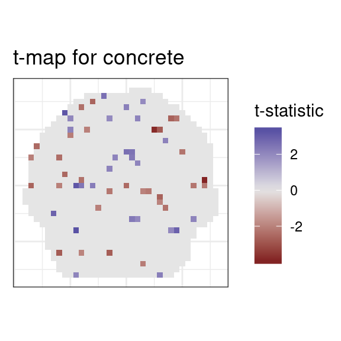

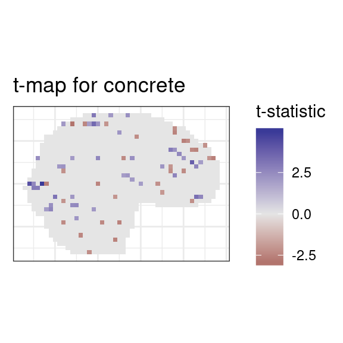

Note that in the above plots, $t$-statistic values below the cutoff at the significance level were set to $0$.

The non-contiguous appearance of the $t$-maps suggests that either the data are too noisy (we are looking at just one session) or there’s something not quite right about the model fit. One thing we can check for (empirically/visually) is goodness of fit of the global signal.

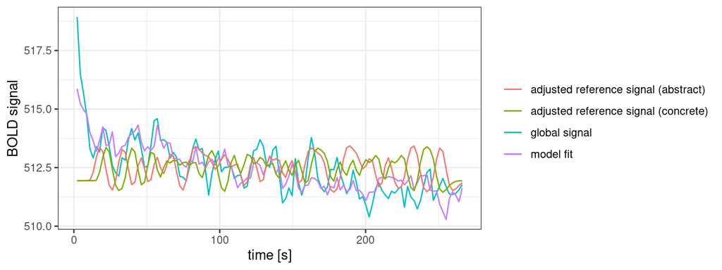

Unfortunately in this model, the reference BOLD signal is not a good predictor of the observed BOLD signal ($p = 0.69$). Looking back to the plot of the regressors, we can see that the rotation along the $x$-axis and translation along the $z$-axis appear to correlate strongly with the global signal.

We can also take a look at the outliers over time:

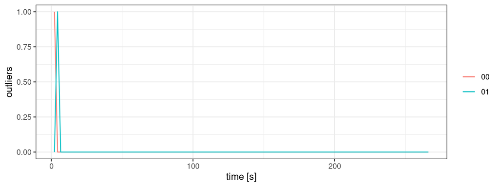

The plots don’t suggest that an abundance of outliers is affecting our models. We can nevertheless try cutting off the first few scans (and perhaps the last few scans):

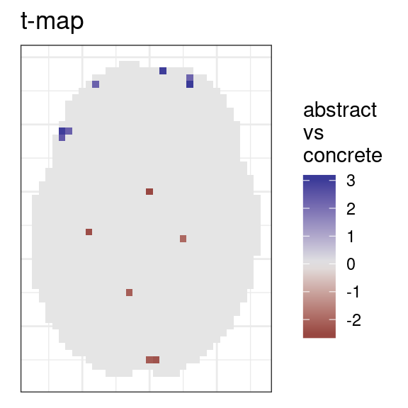

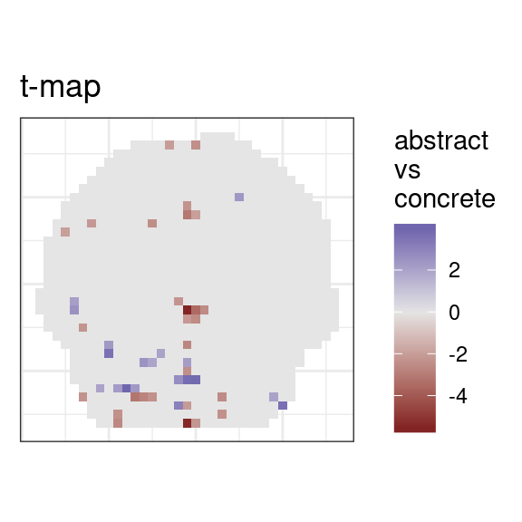

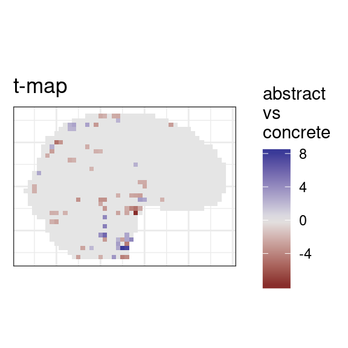

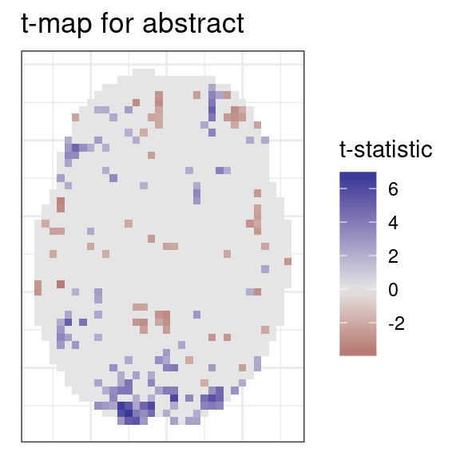

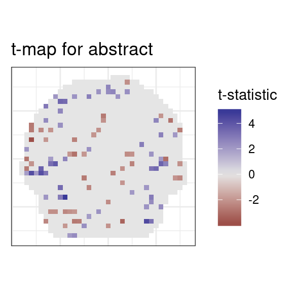

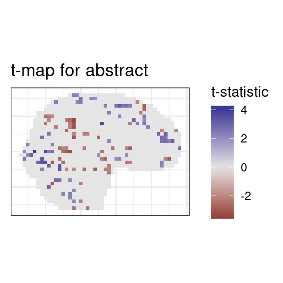

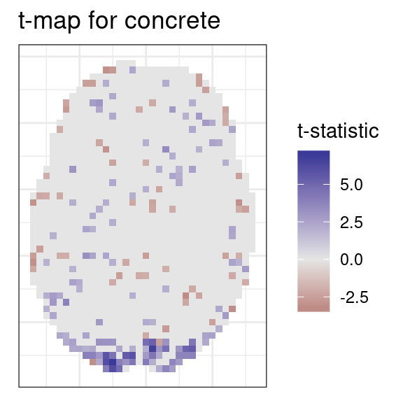

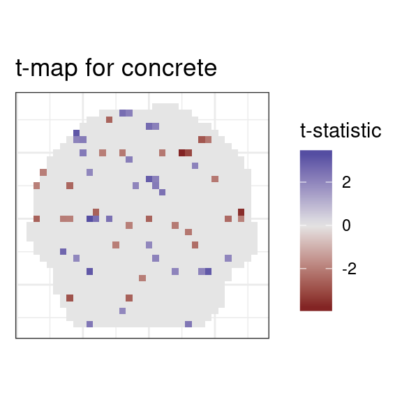

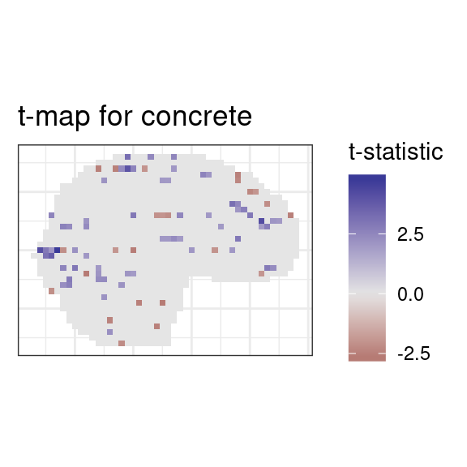